# WECC Cold Weather Analysis

```r
library(tidyverse)
library(mosaic)
library(dplyr)
library(ResourceSelection)
library(readr)
library(pander)

df<- read_csv("weather_summary.csv",
    col_types = cols(avg_temp = col_number()))
```

Authors: JT Twiggs & Sheldon Downs

### Graph and Model

We were tasked by WECC (Western Electric Coordinating Council) to gather weather data for the state of Idaho and create a model that looks for and predicts extreme cold weather. We decided that extreme cold weather would be 10 degrees Fahrenheit or below. Our data was scraped from the web and contain weather data from January 1st 2021 - December 31st 2022. We lagged our data so that our model would predict if the next day would have extreme cold weather biased on the weather data from the day before.

```r
df <- df %>%
  mutate(extream = ifelse(avg_temp <10, 1, 0))
```

```r
bin_conditions <- df %>%
  mutate(condition_bin = case_when(
    condition %in% c('light_snow','ice_fog', 'passing_clouds') ~ 'light_snow',
    condition %in% c('clouds','light_rain','fog',
                  'broken_clouds','partly_sun') ~ 'overcast',
    condition == 'sun' ~ 'sun',
    condition == 'clear' ~ 'clear',
    condition == 'low_clouds' ~ 'low_clouds'
  )) %>%
  mutate(sun_snow = ifelse(condition_bin %in% c('light_snow', 'sun'),1,0))
```

```r
wglm <- glm(extream ~ avg_pressure + month  *  avg_humidity + I(avg_humidity^2) + sun_snow ,data = bin_conditions, family = binomial)
pander(summary(wglm))
```

|  | Estimate | Std. Error | z value | Pr(>\|z\|) |
| --- | --- | --- | --- | --- |
| **(Intercept)** | -222.7 | 55.31 | -4.026 | 5.676e-05 |
| **avg_pressure** | 3.588 | 1.172 | 3.06 | 0.002211 |
| **month** | -3.647 | 1.473 | -2.476 | 0.01329 |
| **avg_humidity** | 331.3 | 118.2 | 2.802 | 0.005078 |
| **I(avg_humidity^2)** | -242.6 | 82.74 | -2.933 | 0.003361 |
| **sun_snow** | 2.641 | 0.7102 | 3.718 | 0.0002009 |
| **month:avg_humidity** | 4.497 | 1.873 | 2.402 | 0.01632 |

(Dispersion parameter for binomial family taken to be 1 )

| Null deviance: | 168.85 on 729 degrees of freedom |
| --- | --- |
| Residual deviance: | 86.15 on 723 degrees of freedom |

```r
b <- coef(wglm)
```

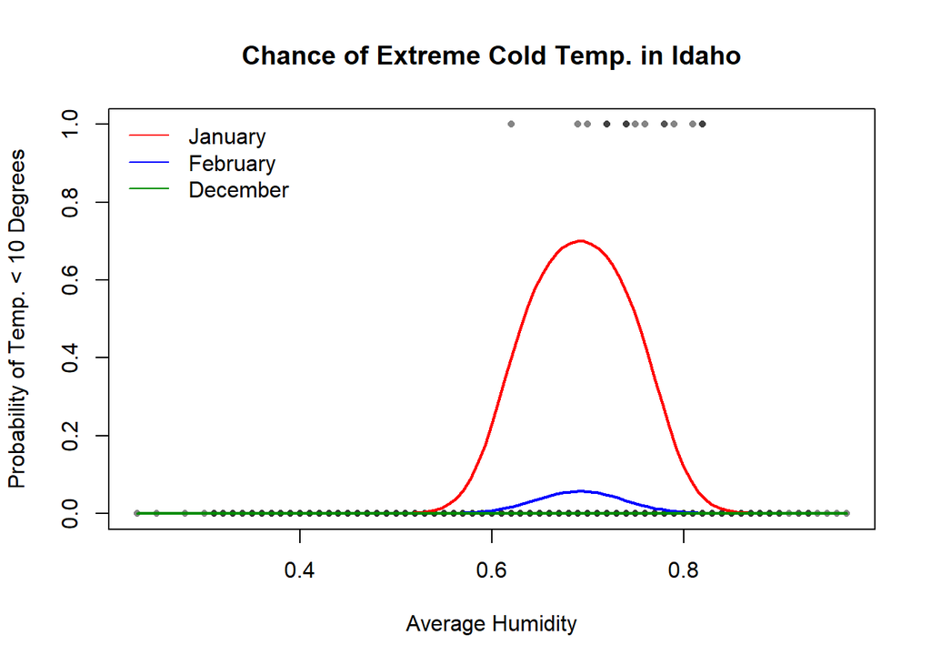

```r
plot(extream==1 ~ avg_humidity, bin_conditions, cex=0.7, pch=16, col=rgb(.2,.2,.2,.6), main = 'Chance of Extreme Cold Temp. in Idaho', xlab = 'Average Humidity', ylab = 'Probability of Temp. < 10 Degrees')
legend("topleft", legend=c("January", "February", 'December'), lty=c(1,1,1), bty="n", col=c('red', 'blue', 'green4'))
x1 = 30.20
x2 = 1
x5 = 1
curve(exp(b[1] + b[2] * x1 + b[3] * x2 + b[4] * x + b[5] * x^2 + b[6] * x5 + b[7] *x  ) / (1+exp(b[1] + b[2] * x1 + b[3] * x2 + b[4] * x + b[5] * x^2 + b[6] * x5 + b[7] *x )), add=TRUE, col = "red", lwd = 2)
#--------
x1 = 30.20
x2 = 2
x5 = 1
curve(exp(b[1] + b[2] * x1 + b[3] * x2 + b[4] * x + b[5] * x^2 + b[6] * x5 + b[7] *x  ) / (1+exp(b[1] + b[2] * x1 + b[3] * x2 + b[4] * x + b[5] * x^2 + b[6] * x5 + b[7] *x )), add=TRUE, col = "blue", lwd = 2)
#--------
x1 = 30.06
x2 = 12
x5 = 1
curve(exp(b[1] + b[2] * x1 + b[3] * x2 + b[4] * x + b[5] * x^2 + b[6] * x5 + b[7] *x  ) / (1+exp(b[1] + b[2] * x1 + b[3] * x2 + b[4] * x + b[5] * x^2 + b[6] * x5 + b[7] *x )), add=TRUE, col = "green4", lwd = 2)
```

This graphic shows three different slices of the model when it would be most likely to have extreme cold weather. Something that stands out from the graph is that there is a range of humitiy from about 0.58 and 0.8 for it to able to be extremely cold

### Validation

```r
set.seed(121)
n <- nrow(bin_conditions)
keep <- sample(1:n, round(0.7*n)) #putSomeNumberHere that is about 60-70% of your data set's size)
mytrain <- bin_conditions[keep, ]
mytest <- bin_conditions[-keep, ]
train.glm <- glm(extream ~ avg_pressure + month * avg_humidity + I(avg_humidity^2) + sun_snow ,data = bin_conditions, family = binomial)
mypreds <- predict(train.glm, mytest, type="response")
callit <- ifelse(mypreds >= 0.4, 1, 0) #you can put whatever you want for the 0.9 value
```

```r
conf_matrix <- table(mytest$extream, callit)
conf_matrix
```

```
##    callit
##       0   1
##   0 214   0
##   1   2   3
```

Model accuracy:

```r
pcc <- (214 + 3)/ (214 + 2 + 3)
pcc
```

```
## [1] 0.9908676
```

### Model Interpretation

```r
winter <- bin_conditions %>%
  filter(month %in% c(1,2,12))
```

```r
wint_glm <- glm(extream ~ avg_pressure + month * avg_humidity + I(avg_humidity^2) + sun_snow ,data = winter, family = binomial)
#summary(wglm)
```

```r
#summary(wglm)
```

```r
library(ResourceSelection)
hoslem.test(wglm$y, wglm$fit, g=10)
```

```
##
##  Hosmer and Lemeshow goodness of fit (GOF) test
##
## data:  wglm$y, wglm$fit
## X-squared = 0.79321, df = 7, p-value = 0.9975
```

```r
odd_coef <- (1- exp(b))
pander(odd_coef)
```

Table continues below

| (Intercept) | avg_pressure | month | avg_humidity | I(avg_humidity^2) |
| --- | --- | --- | --- | --- |
| 1 | -35.16 | 0.9739 | -7.682e+143 | 1 |

| sun_snow | month:avg_humidity |
| --- | --- |
| -13.02 | -88.77 |

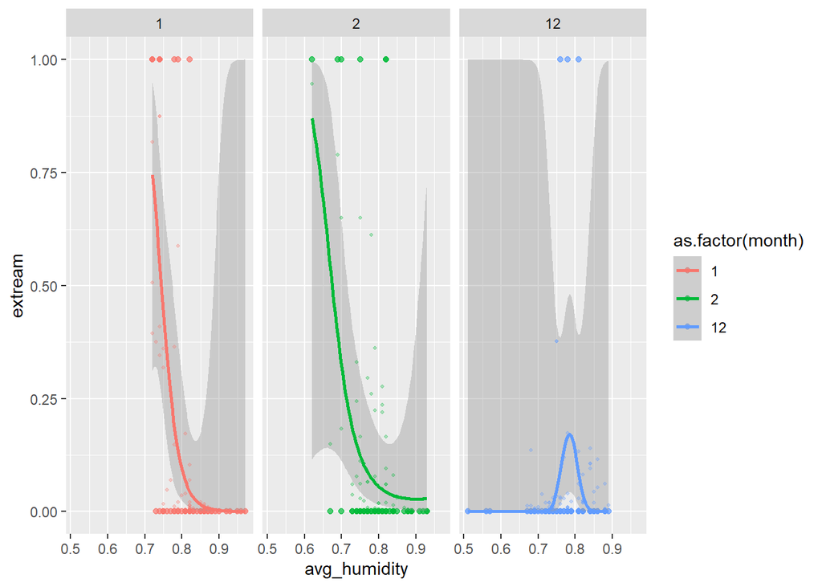

```r
ggplot(winter,
       aes(x = avg_humidity, y = extream,color = as.factor(month))) +
  geom_point(alpha=0.7) +
  geom_smooth(method="glm", formula=y~poly(x,2), method.args=list(family="binomial")) +
  geom_point(aes(y=wint_glm$fit), size=0.8, alpha=0.3) +
  facet_grid(~month)
```

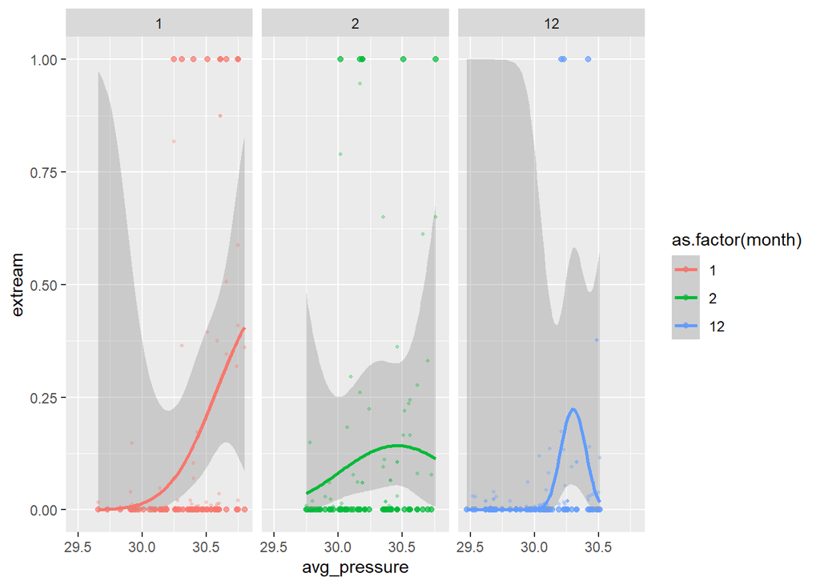

```r
ggplot(winter,
       aes(x = avg_pressure, y = extream,color = as.factor(month))) +
  geom_point(alpha=0.7) +
  geom_smooth(method="glm", formula=y~poly(x,2), method.args=list(family="binomial")) +
  geom_point(aes(y=wint_glm$fit), size=0.8, alpha=0.3) +
  facet_grid(~month)
```